# Get Smart. A visual correlation of mortality, education and freedom.

## CMSC320 Final Tutorial

### Aaron Shavolian

Have you ever wondered what the relationship between mortality, educational attainment and freedom looks like in different countries? here we seek to answer this question by collecting and analysing data from reliable sources such as the Organization for Economic Co-operation and Development (OECD) and the Human Freedom Index (HFI). We will then present this data in a visual representation, allowing viewers to gain valuable insight into how these three factors are linked. Join us on this journey as we explore the correlation between mortality, education and freedom in countries around the world!

# Importing Libraries

The following libraries/tools will be used throughout the project. They will allow us to do and visualize more! If you do not have any of these libraries installed, you can install them into your development environmemt with the help of $ pip3 install [package]. You can find more information on them through their documentation linked below:

- **pandas**: a data analysis toolkit which helps us work with data frames
- **numpy**: a package for scientific computing with special n-d arrays
- **matplotlib**: for graphing
- **seaborn** as sns: For graphs
- **sklearn**: For Macine Learning

```python
import warnings
warnings.filterwarnings('ignore')

import pandas as pd
import numpy as np
import matplotlib.pyplot as plt
import seaborn as sns
from matplotlib.pyplot import hist
import sklearn
from sklearn import metrics
```

# Data Collection

The first step in our project is to gather data. Specifically, I plan to explore the relationship between mortality, education, and freedom in this project. I have found the following resources to be helpful for finding datasets on these topics:

- [Mortality](https://raw.githubusercontent.com/akarlinsky/world_mortality/main/world_mortality.csv)
- [Education](https://stats.oecd.org/sdmx-json/data/DP_LIVE/.EDUADULT.../OECD?contentType=csv&detail=code&separator=comma&csv-lang=en)
- [Freedom](https://www.kaggle.com/datasets/gsutters/the-human-freedom-index)

```python
mortality = pd.read_csv("https://raw.githubusercontent.com/akarlinsky/world_mortality/main/world_mortality.csv")
freedom = pd.read_csv("hfi_cc_2021.csv")
education = pd.read_csv("https://stats.oecd.org/sdmx-json/data/DP_LIVE/.EDUADULT.../OECD?contentType=csv&detail=code&separator=comma&csv-lang=en")
```

```python
mortality.head()
```

|  | iso3c | country_name | year | time | time_unit | deaths |
| --- | --- | --- | --- | --- | --- | --- |
| 0 | ALB | Albania | 2015 | 1 | monthly | 2490.0 |
| 1 | ALB | Albania | 2015 | 2 | monthly | 2139.0 |
| 2 | ALB | Albania | 2015 | 3 | monthly | 2051.0 |
| 3 | ALB | Albania | 2015 | 4 | monthly | 1906.0 |
| 4 | ALB | Albania | 2015 | 5 | monthly | 1709.0 |

```python
freedom.head()
```

|  | year | countries | ISO | region | hf_score | hf_rank | hf_quartile | pf_rol_procedural | pf_rol_civil | pf_rol_criminal | ... | ef_regulation_business_adm | ef_regulation_business_bureaucracy | ef_regulation_business_start | ef_regulation_business_bribes | ef_regulation_business_licensing | ef_regulation_business_compliance | ef_regulation_business | ef_regulation | ef_score | ef_rank |
| --- | --- | --- | --- | --- | --- | --- | --- | --- | --- | --- | --- | --- | --- | --- | --- | --- | --- | --- | --- | --- | --- |
| 0 | 2019 | Albania | ALB | Eastern Europe | 8.14 | 43.0 | 2.0 | 5.97 | 4.76 | 4.26 | ... | 5.65 | 6.67 | 9.74 | 6.24 | 5.62 | 7.18 | 6.85 | 7.70 | 7.81 | 31.0 |
| 1 | 2019 | Algeria | DZA | Middle East & North Africa | 5.26 | 154.0 | 4.0 | 5.21 | 5.64 | 4.35 | ... | 4.22 | 2.22 | 9.31 | 2.58 | 8.77 | 7.03 | 5.69 | 5.84 | 4.90 | 162.0 |
| 2 | 2019 | Angola | AGO | Sub-Saharan Africa | 6.09 | 129.0 | 4.0 | 2.72 | 4.43 | 3.60 | ... | 2.94 | 2.44 | 8.73 | 4.70 | 7.92 | 6.78 | 5.59 | 5.97 | 5.50 | 153.0 |
| 3 | 2019 | Argentina | ARG | Latin America & the Caribbean | 7.38 | 74.0 | 2.0 | 6.83 | 5.94 | 4.35 | ... | 2.71 | 5.78 | 9.58 | 6.53 | 5.73 | 6.51 | 6.14 | 5.99 | 5.50 | 153.0 |
| 4 | 2019 | Armenia | ARM | Caucasus & Central Asia | 8.20 | 40.0 | 1.0 | NaN | NaN | NaN | ... | 5.17 | 5.56 | 9.86 | 6.96 | 9.30 | 7.04 | 7.32 | 7.82 | 8.03 | 15.0 |

5 rows × 125 columns

```python
education.head()
```

|  | LOCATION | INDICATOR | SUBJECT | MEASURE | FREQUENCY | TIME | Value | Flag Codes |
| --- | --- | --- | --- | --- | --- | --- | --- | --- |
| 0 | AUS | EDUADULT | BUPPSRY | PC_25_64 | A | 1989 | 44.650639 | NaN |
| 1 | AUS | EDUADULT | BUPPSRY | PC_25_64 | A | 1991 | 44.127056 | NaN |
| 2 | AUS | EDUADULT | BUPPSRY | PC_25_64 | A | 1993 | 47.159046 | NaN |
| 3 | AUS | EDUADULT | BUPPSRY | PC_25_64 | A | 1994 | 49.802025 | NaN |
| 4 | AUS | EDUADULT | BUPPSRY | PC_25_64 | A | 1995 | 44.935852 | NaN |

# Data Preprocessing

## Data Cleaning

In this step we have to clean the data by removing the columns that are not of our interest and also changing the names of the columns so that it is easy to understand. And also handling the missing data if some values are NaN then we can replace them with mean() or median().

```python
mortality = mortality.rename(columns = {'country_name': 'country', 'iso3c': 'country_code'})
```

```python
mortality = mortality[(mortality['year']==2019)]
mortality_2018 = mortality[(mortality['year']==2018)]
mortality_2017 = mortality[(mortality['year']==2017)]
mortality_2016 = mortality[(mortality['year']==2016)]
mortality_2015 = mortality[(mortality['year']==2015)]
mortality.append(mortality_2018)
mortality.append(mortality_2017)
mortality.append(mortality_2016)
mortality.append(mortality_2015)
```

|  | country_code | country | year | time | time_unit | deaths |
| --- | --- | --- | --- | --- | --- | --- |
| 48 | ALB | Albania | 2019 | 1 | monthly | 2397.0 |
| 49 | ALB | Albania | 2019 | 2 | monthly | 1974.0 |
| 50 | ALB | Albania | 2019 | 3 | monthly | 1990.0 |
| 51 | ALB | Albania | 2019 | 4 | monthly | 1687.0 |
| 52 | ALB | Albania | 2019 | 5 | monthly | 1744.0 |
| ... | ... | ... | ... | ... | ... | ... |
| 26702 | UZB | Uzbekistan | 2019 | 8 | monthly | 12292.0 |
| 26703 | UZB | Uzbekistan | 2019 | 9 | monthly | 10851.0 |
| 26704 | UZB | Uzbekistan | 2019 | 10 | monthly | 11948.0 |
| 26705 | UZB | Uzbekistan | 2019 | 11 | monthly | 12273.0 |
| 26706 | UZB | Uzbekistan | 2019 | 12 | monthly | 18196.0 |

3504 rows × 6 columns

As there we have seen that there are many values of deaths with the same **country_code** so we have to apply groupby function so that group the deaths with the same country_code. This will take the **sum** of entries in the column "deaths" with the same corresponding country_code.

```python
mortality = mortality.groupby(['country_code'],as_index=False).sum()
mortality = mortality.drop(['time', 'year'], axis = 1)
mortality
```

|  | country_code | deaths |
| --- | --- | --- |
| 0 | ABW | 665.0 |
| 1 | ALB | 21937.0 |
| 2 | AND | 301.0 |
| 3 | ARG | 341055.0 |
| 4 | ARM | 26252.0 |
| ... | ... | ... |
| 117 | URY | 34807.0 |
| 118 | USA | 2852633.0 |
| 119 | UZB | 154570.0 |
| 120 | VCT | 1023.0 |
| 121 | ZAF | 525457.0 |

122 rows × 2 columns

Changing Names of variables so that we can group them later

```python
freedom = freedom.rename(columns = {'countries': 'country', 'ISO': 'country_code'})
```

```python
freedom = freedom[freedom['year'] == 2019]
freedom_2018 = freedom[freedom['year'] == 2018]
freedom_2017 = freedom[freedom['year'] == 2017]
freedom_2016 = freedom[freedom['year'] == 2016]
freedom_2015 = freedom[freedom['year'] == 2015]
freedom.append(freedom_2018)
freedom.append(freedom_2017)
freedom.append(freedom_2016)
freedom.append(freedom_2015)
freedom = freedom[['country_code', 'country', 'hf_score']]
```

```python
freedom.head()
```

|  | country_code | country | hf_score |
| --- | --- | --- | --- |
| 0 | ALB | Albania | 8.14 |
| 1 | DZA | Algeria | 5.26 |
| 2 | AGO | Angola | 6.09 |
| 3 | ARG | Argentina | 7.38 |
| 4 | ARM | Armenia | 8.20 |

```python
education = education.rename(columns = {'LOCATION': 'country_code', 'ISO': 'country_code', 'Value': 'education_score'})
```

```python
#create a dataframe representing the average education
#filter by tertiary education only
education = education[education['TIME'] == 2019]
education_2018 = education[education['TIME'] == 2018]
education_2017 = education[education['TIME'] == 2017]
education_2016 = education[education['TIME'] == 2016]
education_2015 = education[education['TIME'] == 2015]
education.append(education_2018)
education.append(education_2017)
education.append(education_2016)
education.append(education_2015)
```

|  | country_code | INDICATOR | SUBJECT | MEASURE | FREQUENCY | TIME | education_score | Flag Codes |
| --- | --- | --- | --- | --- | --- | --- | --- | --- |
| 27 | AUS | EDUADULT | BUPPSRY | PC_25_64 | A | 2019 | 17.132658 | NaN |
| 57 | AUS | EDUADULT | TRY | PC_25_64 | A | 2019 | 47.129978 | NaN |
| 87 | AUS | EDUADULT | UPPSRY | PC_25_64 | A | 2019 | 35.737366 | NaN |
| 105 | AUT | EDUADULT | BUPPSRY | PC_25_64 | A | 2019 | 14.435863 | NaN |
| 123 | AUT | EDUADULT | TRY | PC_25_64 | A | 2019 | 33.773777 | NaN |
| ... | ... | ... | ... | ... | ... | ... | ... | ... |
| 7280 | IND | EDUADULT | UPPSRY_WOMEN | PC_25_64 | A | 2019 | 6.939596 | NaN |
| 7297 | LTU | EDUADULT | UPPSRY_MEN | PC_25_64 | A | 2019 | 55.670059 | NaN |
| 7315 | LTU | EDUADULT | UPPSRY_WOMEN | PC_25_64 | A | 2019 | 44.821220 | NaN |
| 7322 | G20 | EDUADULT | UPPSRY_MEN | PC_25_64 | A | 2019 | 35.571486 | NaN |
| 7328 | G20 | EDUADULT | UPPSRY_WOMEN | PC_25_64 | A | 2019 | 32.380190 | NaN |

304 rows × 8 columns

Here we are selecting the education rown in which the subject contains TRY word (adult education level).

```python
education = education[education['SUBJECT'].str.contains('TRY')]
```

```python
education = education.groupby(['country_code']).mean()
```

```python
education = education.drop(['Flag Codes', 'TIME'], axis = 1)
education = education.sort_values(by=['education_score'], ascending=False)
```

```python
education.head()
```

| country_code | education_score |
| --- | --- |
| CAN | 59.355271 |
| JPN | 52.684597 |
| LUX | 51.674805 |
| ISR | 50.203833 |
| KOR | 50.002234 |

# Merge our data

We need to merge the data on freedom, education, and mortality to perform an analysis on these columns to check for correlations. In the merged data, we will only use the columns of interest

```python
# merging datasets
merged_df = pd.merge(mortality, education, on="country_code")
merged_df = pd.merge(merged_df, freedom, on="country_code")

# visualizing correlation
# import seaborn as sns
# sns.pairplot(merged_df[["Adult literacy rate (%)","Total death rate (per 1,000 people)","hfi_score"]], kind="reg")
merged_df = merged_df[['country', 'country_code', 'deaths', 'education_score', 'hf_score']]
merged_df = merged_df.rename(columns = {'hf_score': 'freedom_score'})
merged_df
```

|  | country | country_code | deaths | education_score | freedom_score |
| --- | --- | --- | --- | --- | --- |
| 0 | Argentina | ARG | 341055.0 | 22.699922 | 7.38 |
| 1 | Australia | AUS | 164372.0 | 47.084581 | 8.84 |
| 2 | Austria | AUT | 81485.0 | 33.774050 | 8.67 |
| 3 | Belgium | BEL | 108436.0 | 40.672868 | 8.61 |
| 4 | Brazil | BRA | 1349801.0 | 18.667221 | 7.22 |
| 5 | Canada | CAN | 284315.0 | 59.355271 | 8.85 |
| 6 | Switzerland | CHE | 67515.0 | 44.392679 | 9.11 |
| 7 | Colombia | COL | 241281.0 | 23.775358 | 7.01 |
| 8 | Costa Rica | CRI | 24292.0 | 25.056263 | 8.25 |
| 9 | Czech Republic | CZE | 112040.0 | 24.234717 | 8.61 |
| 10 | Germany | DEU | 936772.0 | 29.889195 | 8.73 |
| 11 | Denmark | DNK | 53805.0 | 40.376915 | 8.98 |
| 12 | Spain | ESP | 414914.0 | 38.589302 | 8.56 |
| 13 | Estonia | EST | 15332.0 | 41.357241 | 8.91 |
| 14 | Finland | FIN | 53820.0 | 46.008930 | 8.85 |
| 15 | France | FRA | 597917.0 | 37.853518 | 8.34 |
| 16 | United Kingdom | GBR | 600532.0 | 47.163578 | 8.75 |
| 17 | Greece | GRC | 124538.0 | 31.877590 | 7.86 |
| 18 | Hungary | HUN | 129266.0 | 25.952007 | 7.73 |
| 19 | Ireland | IRL | 31270.0 | 47.265182 | 8.90 |
| 20 | Iceland | ISL | 2261.0 | 41.154638 | 8.77 |
| 21 | Israel | ISR | 45813.0 | 50.203833 | 7.66 |
| 22 | Italy | ITA | 642964.0 | 19.676718 | 8.49 |
| 23 | Japan | JPN | 1387775.0 | 52.684597 | 8.73 |
| 24 | Korea, Rep. | KOR | 294080.0 | 50.002234 | 8.39 |
| 25 | Lithuania | LTU | 38184.0 | 43.029096 | 8.68 |
| 26 | Luxembourg | LUX | 4288.0 | 51.674805 | 8.80 |
| 27 | Latvia | LVA | 27632.0 | 35.519443 | 8.67 |
| 28 | Mexico | MEX | 731233.0 | 18.285744 | 6.92 |
| 29 | Netherlands | NLD | 151543.0 | 40.384846 | 8.78 |
| 30 | Norway | NOR | 40458.0 | 44.209381 | 8.76 |
| 31 | New Zealand | NZL | 34088.0 | 38.999611 | 9.01 |
| 32 | Poland | POL | 407624.0 | 31.995470 | 7.96 |
| 33 | Portugal | PRT | 111474.0 | 26.143672 | 8.69 |
| 34 | Slovak Republic | SVK | 53115.0 | 25.801743 | 8.21 |
| 35 | Slovenia | SVN | 20547.0 | 33.433442 | 8.37 |
| 36 | Sweden | SWE | 88544.7 | 44.060315 | 8.83 |
| 37 | United States | USA | 2852633.0 | 48.299706 | 8.73 |
| 38 | South Africa | ZAF | 525457.0 | 15.790772 | 7.30 |

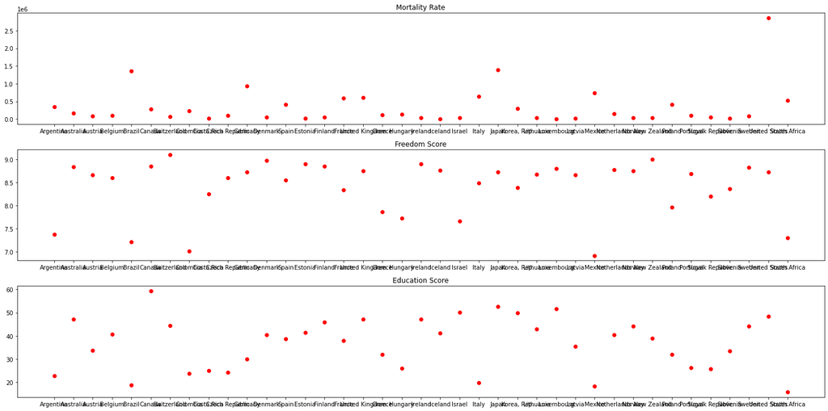

```python
fig, axes = plt.subplots(nrows=3, ncols=1, figsize=(10, 10))

# Plot mortality rate
axes[0].scatter(merged_df['country'], merged_df['deaths'],c='red')
axes[0].set_title('Mortality Rate')

# Plot Freedom Score
axes[1].scatter(merged_df['country'], merged_df['freedom_score'],c='red')
axes[1].set_title('Freedom Score')

# Plot Education Score
axes[2].scatter(merged_df['country'], merged_df['education_score'],c='red')
axes[2].set_title('Education Score')

# Show plot
fig.set_figwidth(20)
fig.set_figheight(10)
plt.tight_layout()
plt.show()
```

### Oops!

**As we can see, the death rates are too high to compare with the freedom and education rates, so we need to scale the death rates according to the population of the country in order to see the correlation between these variables**

## Convert deaths to mortality rate

We need to import a population dataset so that we can adjust our mortality rate. We have observed that the values for deaths are much larger compared to the values for freedom rate and education rate.

```python
# now we need to adjust the deaths column to be per-capita
populations = pd.read_csv("Data_Extract_FromWorld Development Indicators.csv", index_col=[0], thousands=',')
populations['country'] = populations.index
populations.reset_index(inplace=True)
populations = populations[['country', '2019']]
populations = populations.rename(columns = {'2019': 'population'})

merged_df = pd.merge(merged_df, populations, on='country')
merged_df
```

|  | country | country_code | deaths | education_score | freedom_score | population |
| --- | --- | --- | --- | --- | --- | --- |
| 0 | Argentina | ARG | 341055.0 | 22.699922 | 7.38 | 44,938,712.0 |
| 1 | Australia | AUS | 164372.0 | 47.084581 | 8.84 | 25,365,745.0 |
| 2 | Austria | AUT | 81485.0 | 33.774050 | 8.67 | 8,879,920.0 |
| 3 | Belgium | BEL | 108436.0 | 40.672868 | 8.61 | 11,488,980.0 |
| 4 | Brazil | BRA | 1349801.0 | 18.667221 | 7.22 | 211,049,519.0 |
| 5 | Canada | CAN | 284315.0 | 59.355271 | 8.85 | 37,601,230.0 |
| 6 | Switzerland | CHE | 67515.0 | 44.392679 | 9.11 | 8,575,280.0 |
| 7 | Colombia | COL | 241281.0 | 23.775358 | 7.01 | 50,339,443.0 |
| 8 | Costa Rica | CRI | 24292.0 | 25.056263 | 8.25 | 5,047,561.0 |
| 9 | Germany | DEU | 936772.0 | 29.889195 | 8.73 | 83,092,962.0 |
| 10 | Denmark | DNK | 53805.0 | 40.376915 | 8.98 | 5,814,422.0 |
| 11 | Spain | ESP | 414914.0 | 38.589302 | 8.56 | 47,134,837.0 |
| 12 | Estonia | EST | 15332.0 | 41.357241 | 8.91 | 1,326,855.0 |
| 13 | Finland | FIN | 53820.0 | 46.008930 | 8.85 | 5,521,606.0 |
| 14 | France | FRA | 597917.0 | 37.853518 | 8.34 | 67,248,926.0 |
| 15 | United Kingdom | GBR | 600532.0 | 47.163578 | 8.75 | 66,836,327.0 |
| 16 | Greece | GRC | 124538.0 | 31.877590 | 7.86 | 10,721,582.0 |
| 17 | Hungary | HUN | 129266.0 | 25.952007 | 7.73 | 9,771,141.0 |
| 18 | Ireland | IRL | 31270.0 | 47.265182 | 8.90 | 4,934,340.0 |
| 19 | Iceland | ISL | 2261.0 | 41.154638 | 8.77 | 360,563.0 |
| 20 | Israel | ISR | 45813.0 | 50.203833 | 7.66 | 9,054,000.0 |
| 21 | Italy | ITA | 642964.0 | 19.676718 | 8.49 | 59,729,081.0 |
| 22 | Japan | JPN | 1387775.0 | 52.684597 | 8.73 | 126,633,000.0 |
| 23 | Korea, Rep. | KOR | 294080.0 | 50.002234 | 8.39 | 51,764,822.0 |
| 24 | Lithuania | LTU | 38184.0 | 43.029096 | 8.68 | 2,794,137.0 |
| 25 | Luxembourg | LUX | 4288.0 | 51.674805 | 8.80 | 620,001.0 |
| 26 | Latvia | LVA | 27632.0 | 35.519443 | 8.67 | 1,913,822.0 |
| 27 | Mexico | MEX | 731233.0 | 18.285744 | 6.92 | 127,575,529.0 |
| 28 | Netherlands | NLD | 151543.0 | 40.384846 | 8.78 | 17,344,874.0 |
| 29 | Norway | NOR | 40458.0 | 44.209381 | 8.76 | 5,347,896.0 |
| 30 | New Zealand | NZL | 34088.0 | 38.999611 | 9.01 | 4,979,200.0 |
| 31 | Poland | POL | 407624.0 | 31.995470 | 7.96 | 37,965,475.0 |
| 32 | Portugal | PRT | 111474.0 | 26.143672 | 8.69 | 10,286,263.0 |
| 33 | Slovak Republic | SVK | 53115.0 | 25.801743 | 8.21 | 5,454,147.0 |
| 34 | Slovenia | SVN | 20547.0 | 33.433442 | 8.37 | 2,088,385.0 |
| 35 | Sweden | SWE | 88544.7 | 44.060315 | 8.83 | 10,278,887.0 |
| 36 | United States | USA | 2852633.0 | 48.299706 | 8.73 | 328,329,953.0 |
| 37 | South Africa | ZAF | 525457.0 | 15.790772 | 7.30 | 58,558,267.0 |

```python
merged_df['deaths'] = merged_df['deaths'] / merged_df['population'].str.replace(',', '').astype(float)
merged_df = merged_df.drop(['population'], axis = 1)
merged_df.to_csv('education_freedom_mortality.csv')
```

**Exploratiry Data Analysis**

In the Exploratiry data Analysis first step we will check the

- mean
- median
- Standard Deviation
- Minimum
- Maximum

**Mortality Rate**

```python
mean = np.mean(merged_df['deaths'])
median = np.median(merged_df['deaths'])
mini = np.min(merged_df['deaths'])
maxi = np.max(merged_df['deaths'])
stddev = np.std(merged_df['deaths'])
print('SUMMARY STATS FOR Mortality Rate')
print('Mean: ', mean, '\nStd Dev: ', stddev, '\nMedian: ', median, '\nMin: ', mini, '\nMax: ', maxi)
```

```
SUMMARY STATS FOR Mortality Rate
Mean:  0.008786138668360302
Std Dev:  0.0023969909397209563
Median:  0.008846902357447301
Min:  0.004793080447870668
Max:  0.014438124339672133
```

**Freedom Rate**

```python
mean = np.mean(merged_df['freedom_score'])
median = np.median(merged_df['freedom_score'])
mini = np.min(merged_df['freedom_score'])
maxi = np.max(merged_df['freedom_score'])
stddev = np.std(merged_df['freedom_score'])
print('SUMMARY STATS FOR Freedom Rate')
print('Mean: ', mean, '\nStd Dev: ', stddev, '\nMedian: ', median, '\nMin: ', mini, '\nMax: ', maxi)
```

```
SUMMARY STATS FOR Freedom Rate
Mean:  8.40263157894737
Std Dev:  0.5898781507116369
Median:  8.675
Min:  6.92
Max:  9.11
```

**Education Rate**

```python
mean = np.mean(merged_df['education_score'])
median = np.median(merged_df['education_score'])
mini = np.min(merged_df['education_score'])
maxi = np.max(merged_df['education_score'])
stddev = np.std(merged_df['education_score'])
print('SUMMARY STATS FOR Education Rate')
print('Mean: ', mean, '\nStd Dev: ', stddev, '\nMedian: ', median, '\nMin: ', mini, '\nMax: ', maxi)
```

```
SUMMARY STATS FOR Education Rate
Mean:  37.18846671052631
Std Dev:  10.937403605963052
Median:  39.688262833333326
Min:  15.790771999999999
Max:  59.35527066666666
```

## Visualize our data using scatter plots

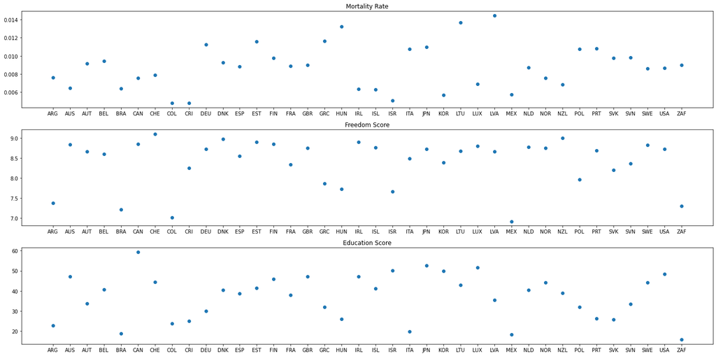

```python
# Create charts to display mortality_rate, freedom_score, and education_score of each country
fig, axes = plt.subplots(nrows=3, ncols=1, figsize=(10, 10))

# Plot mortality rate
axes[0].scatter(merged_df['country_code'], merged_df['deaths'])
axes[0].set_title('Mortality Rate')

# Plot Freedom Score
axes[1].scatter(merged_df['country_code'], merged_df['freedom_score'])
axes[1].set_title('Freedom Score')

# Plot Education Score
axes[2].scatter(merged_df['country_code'], merged_df['education_score'])
axes[2].set_title('Education Score')

# Show plot
fig.set_figwidth(20)
fig.set_figheight(10)
plt.tight_layout()
plt.show()
```

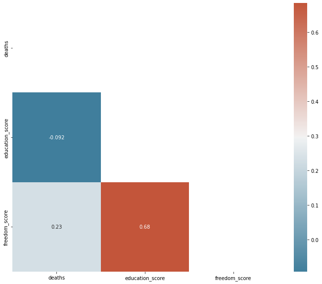

```python
corr = merged_df.corr()
#
# Set up the matplotlib plot configuration
#
f, ax = plt.subplots(figsize=(12, 10))
#
# Generate a mask for upper traingle
#
mask = np.triu(np.ones_like(corr, dtype=bool))
#
# Configure a custom diverging colormap
#
cmap = sns.diverging_palette(230, 20, as_cmap=True)
#
# Draw the heatmap
#
sns.heatmap(corr, annot=True, mask = mask, cmap=cmap)
```

Here I have used the heat map to check the correlation between the mortality,freedom and education. A heat map is a two-dimensional representation of information with the help of colors. Heat maps can help the user visualize simple or complex information. Heat maps are used in many areas such as defense, marketing and understanding consumer behavior. Heat maps can be created with the help of software applications such as Microsoft Excel and others.

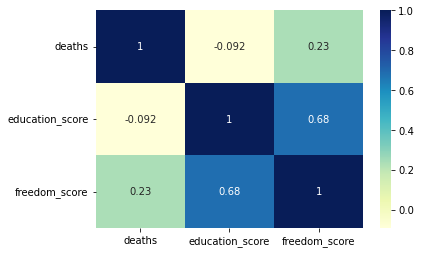

```python
dataplot=sns.heatmap(corr, cmap="YlGnBu", annot=True)
# displaying heatmap
plt.show()
```

**Linear Regression**

Linear regression is a commonly used method for analyzing the relationship between a dependent variable and one or more independent variables. The goal of regression is to assess whether the independent variables are good predictors of the dependent variable and to identify which independent variables have a significant impact on the dependent variable, as indicated by the magnitude and sign of the beta estimates. The regression equation is expressed as y = c + b*x, where y is the predicted value of the dependent variable, c is a constant, b is the regression coefficient, and x is the value of the independent variable. The dependent variable may also be referred to as the outcome variable, criterion variable, endogenous variable, or regressand, while the independent variables may be called exogenous variables, predictor variables, or regressors.

```python
from sklearn.linear_model import LinearRegression
from sklearn.model_selection import train_test_split
from sklearn.linear_model import Ridge
from sklearn.linear_model import Lasso
```

We are using the freedom_score and mortality rate to prdict the value of the education score

```python
X=merged_df.drop(['education_score','country','country_code'],axis=1)
y=merged_df['education_score']
```

```python
X_train,X_test,y_train,y_test=train_test_split(X,y,test_size=0.3)
```

```python
model=LinearRegression()
```

```python
model.fit(X_train,y_train)
```

```
LinearRegression()
```

```python
predicted=model.predict(X_test)
```

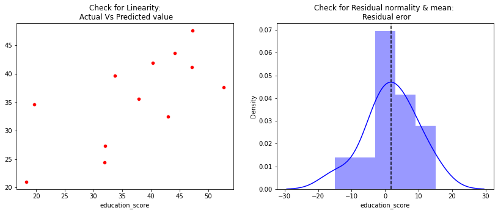

```python
# Check for Linearity
f = plt.figure(figsize=(14,5))
ax = f.add_subplot(121)
sns.scatterplot(y_test,predicted,ax=ax,color='r')
ax.set_title('Check for Linearity:\n Actual Vs Predicted value')

# Check for Residual normality & mean
ax = f.add_subplot(122)
sns.distplot((y_test-predicted),ax=ax,color='b')
ax.axvline((y_test-predicted).mean(),color='k',linestyle='--')
ax.set_title('Check for Residual normality & mean: \n Residual eror');
```

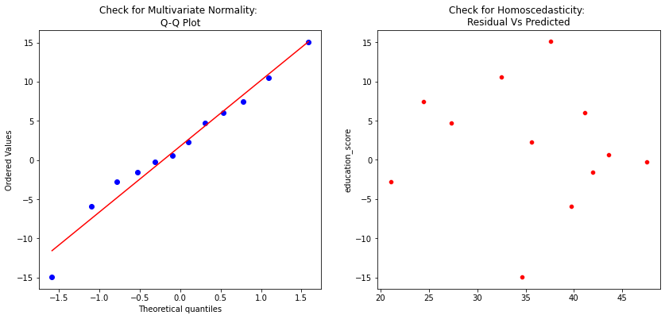

```python
# Check for Multivariate Normality
# Quantile-Quantile plot
f,ax = plt.subplots(1,2,figsize=(14,6))
import scipy as sp
_,(_,_,r)= sp.stats.probplot((y_test-predicted),fit=True,plot=ax[0])
ax[0].set_title('Check for Multivariate Normality: \nQ-Q Plot')

#Check for Homoscedasticity
sns.scatterplot(y = (y_test-predicted), x= predicted, ax = ax[1],color='r')
ax[1].set_title('Check for Homoscedasticity: \nResidual Vs Predicted');
```

```python
print(model.score(X_train, y_train))
print(model.score(X_test, y_test))
```

```
0.5594107935007273
0.4269313322877907
```

**Lasso Regression**  
Lasso is a modification of linear regression, where the model is penalized for the sum of absolute values of the weights. The absolute values of weight will be (in general) reduced, and many will tend to be zeros.

```python
model=Lasso()
```

```python
model.fit(X_train,y_train)
```

```
Lasso()
```

```python
predicted=model.predict(X_test)
```

```python
print(model.score(X_train, y_train))
print(model.score(X_test, y_test))
```

```
0.4192008627397711
0.4891169235863141
```

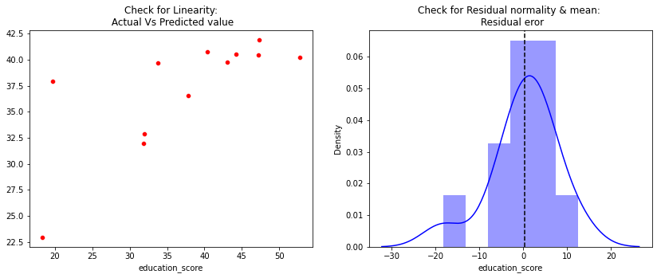

```python
# Check for Linearity
f = plt.figure(figsize=(14,5))
ax = f.add_subplot(121)
sns.scatterplot(y_test,predicted,ax=ax,color='r')
ax.set_title('Check for Linearity:\n Actual Vs Predicted value')

# Check for Residual normality & mean
ax = f.add_subplot(122)
sns.distplot((y_test-predicted),ax=ax,color='b')
ax.axvline((y_test-predicted).mean(),color='k',linestyle='--')
ax.set_title('Check for Residual normality & mean: \n Residual eror');
```

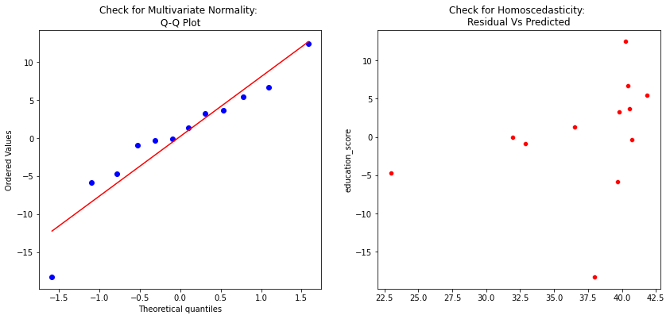

```python
# Check for Multivariate Normality
# Quantile-Quantile plot
f,ax = plt.subplots(1,2,figsize=(14,6))
import scipy as sp
_,(_,_,r)= sp.stats.probplot((y_test-predicted),fit=True,plot=ax[0])
ax[0].set_title('Check for Multivariate Normality: \nQ-Q Plot')

#Check for Homoscedasticity
sns.scatterplot(y = (y_test-predicted), x= predicted, ax = ax[1],color='r')
ax[1].set_title('Check for Homoscedasticity: \nResidual Vs Predicted');
```